# STATS 216: HW4

Xiangpeng Li

```r
set.seed(1)
x = matrix(rnorm(25 * 3 * 45, mean = 0), ncol = 45)

# shift mean
x[1:25, 1:45] = x[1:25, 1:45] + 3
x[26:50, 1:45] = x[26:50, 1:45] - 3
x[51:75, 1:45] = x[51:75, 1:45] + 7
```

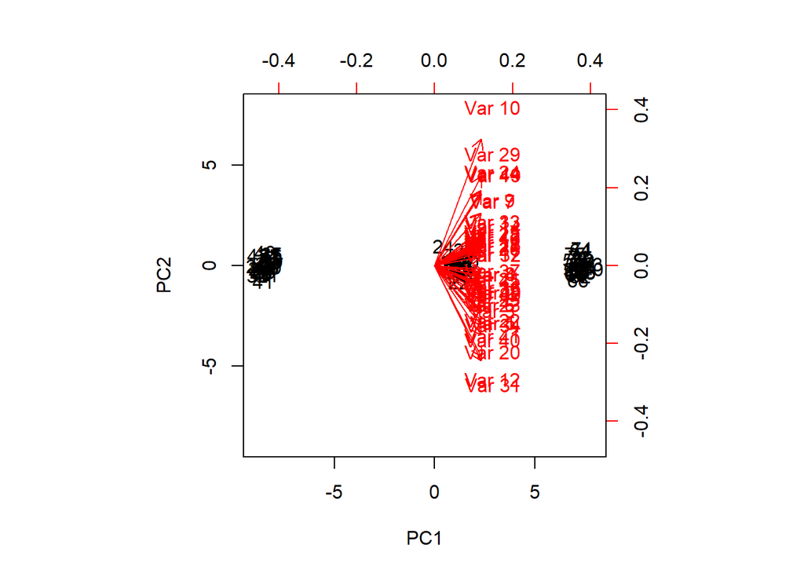

```r
# perform PCA
pca.fit = prcomp(x, scale = TRUE)
biplot(pca.fit, scale = 0)
```

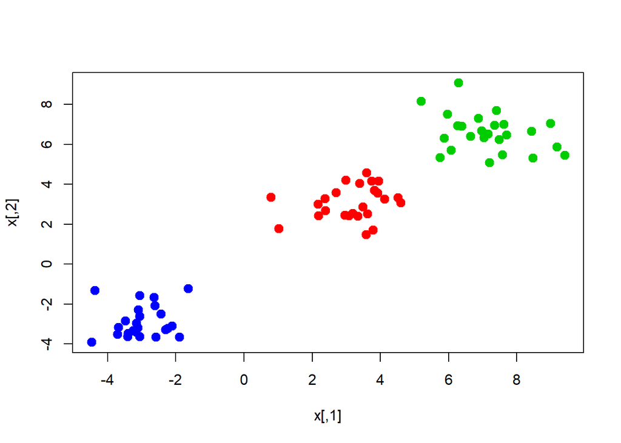

```r
# perform K-means
kmeans3 = kmeans(x, 3, nstart = 20)

plot(x, col = (kmeans3$cluster + 1), pch = 20, cex = 2)
```

```r
table(kmeans3$cluster, c(rep(2, 25), rep(1, 25), rep(3, 25)))
```

```
##
##      1  2  3
##   1  0 25  0
##   2  0  0 25
##   3 25  0  0
```

Since K-means will arbitrarily number the cluster, the label may not be correct, but we can clearly see the predictors are correctly clustered,

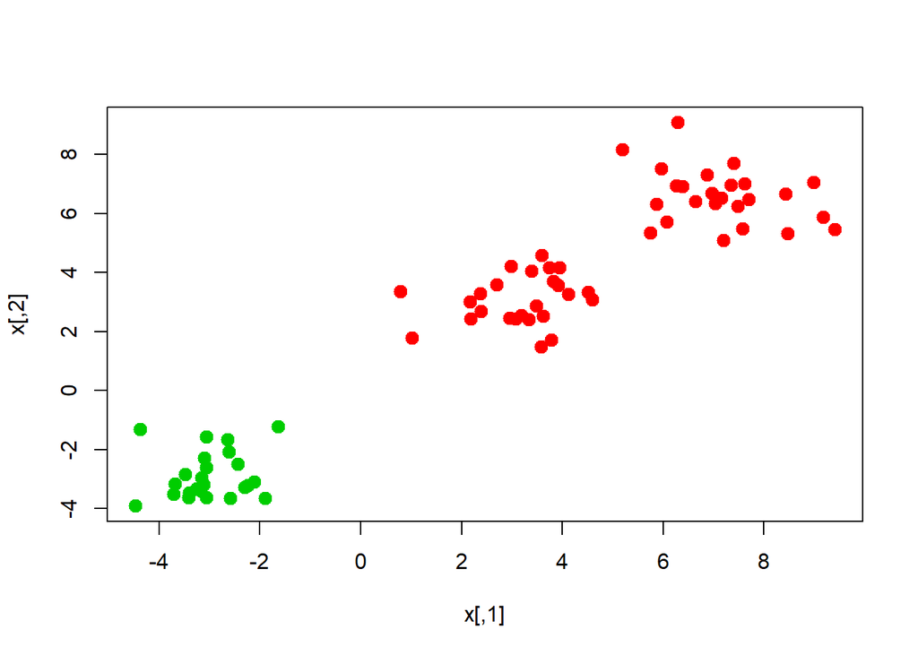

```r
kmeans2 = kmeans(x, 2, nstart = 20)

plot(x, col = (kmeans2$cluster + 1), pch = 20, cex = 2)
```

```r
table(kmeans2$cluster, c(rep(2, 25), rep(1, 25), rep(3, 25)))
```

```
##
##      1  2  3
##   1  0 25 25
##   2 25  0  0
```

As we can see in the plot and table, all the observations in one group are fully labeled as another group.

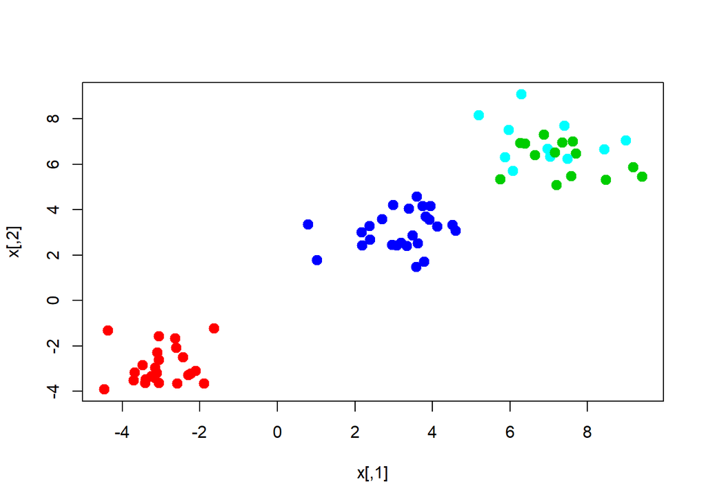

```r
kmeans4 = kmeans(x, 4, nstart = 20)

plot(x, col = (kmeans4$cluster + 1), pch = 20, cex = 2)
```

```r
table(kmeans4$cluster, c(rep(2, 25), rep(1, 25), rep(3, 25)))
```

```
##
##      1  2  3
##   1 25  0  0
##   2  0  0 14
##   3  0 25  0
##   4  0  0 11
```

In this fit, observations from top right are divided into two clusters.

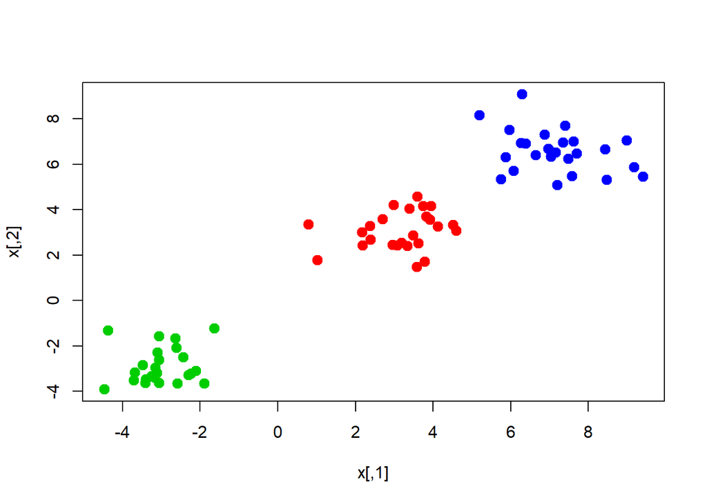

```r
kmeans.pca.fit = kmeans(pca.fit$x[1:75, 1:2], 3, nstart = 20)

plot(x, col = (kmeans.pca.fit$cluster + 1), pch = 20, cex = 2)
```

```r
table(kmeans.pca.fit$cluster, c(rep(2, 25), rep(1, 25), rep(3, 25)))
```

```
##
##      1  2  3
##   1  0 25  0
##   2 25  0  0
##   3  0  0 25
```

All the observations are correctly labeled. It means that first and second components explain the majority of the observations.

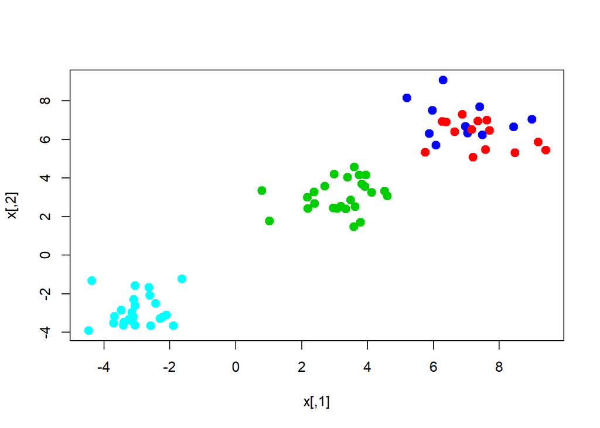

```r
kmeansScale = kmeans(scale(x), 4, nstart = 20)

plot(x, col = (kmeansScale$cluster + 1), pch = 20, cex = 2)
```

```r
table(kmeansScale$cluster, c(rep(2, 25), rep(1, 25), rep(3, 25)))
```

```
##
##      1  2  3
##   1  0  0 14
##   2  0 25  0
##   3  0  0 11
##   4 25  0  0
```

```r
# setup data
setwd("D:/One Drive/OneDrive/Document/Study/Stanford/Introduction to Statistical Learning/homework/hw4")
load("body.RData")
set.seed(1)
traingIndex = sample(seq_len(nrow(X)), size = 307)

training = X[traingIndex, ]
trainRes = Y[traingIndex, ]

test = X[-traingIndex, ]
testRes = Y[-traingIndex, ]
```

4

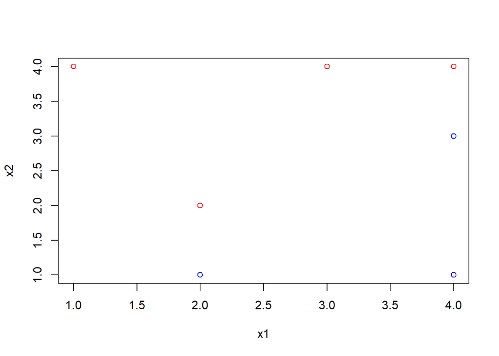

```r
x1 = c(3, 2, 4, 1, 2, 4, 4)
x2 = c(4, 2, 4, 4, 1, 3, 1)
y = c("red", "red", "red", "red", "blue", "blue", "blue")

plot(x1, x2, col = y, type = "p")
```

2. As we can see from above figure, points $(2, 1), (2, 2), (4, 4), (4, 3)$ are the supporting vector, the boundary has to be within that region. In order to get the maximum margin, we can conclude the line has to pass through $(2, 1.5), (4, 3.5)$. So the equation will be
   $$-0.5 + x1 - x2 = 0$$

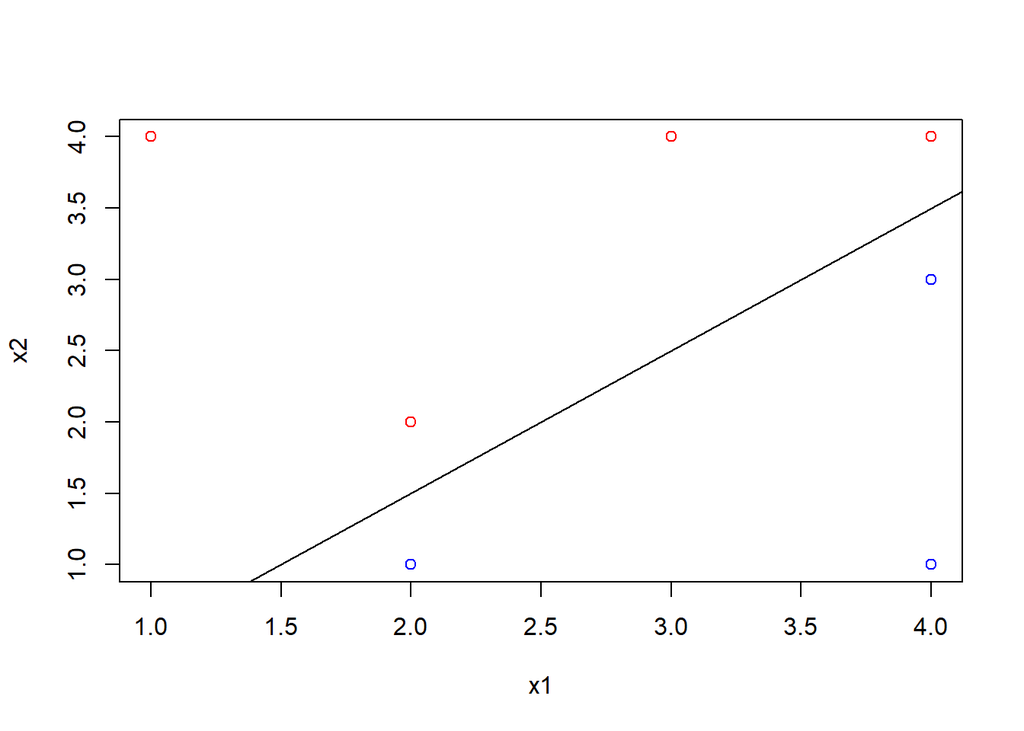

```r
plot(x1, x2, col=y, type = "p")
abline(a = -0.5, b = 1)
```

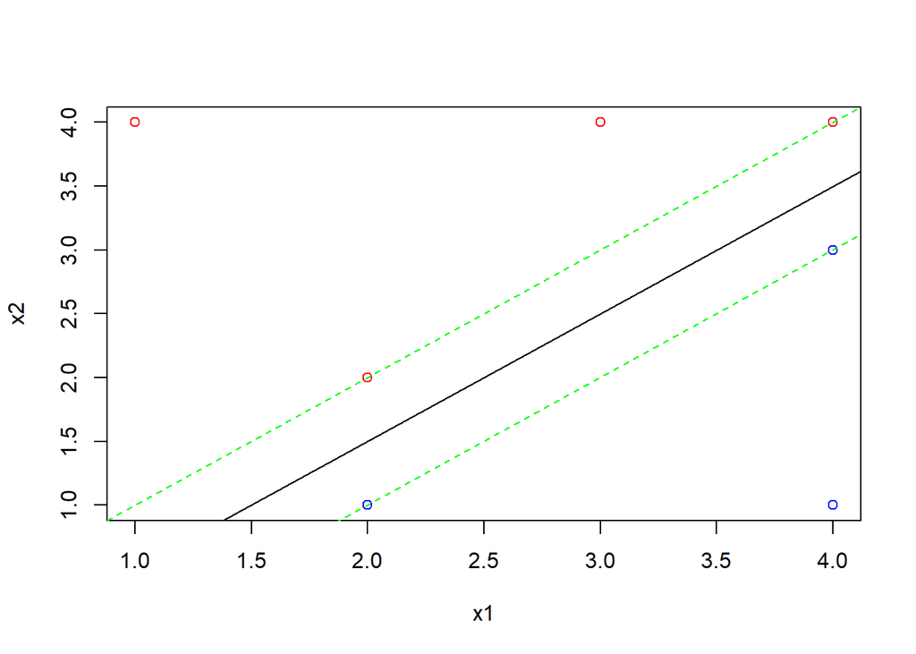

```r
plot(x1, x2, col=y, type = "p")
abline(a = -1, b = 1, col="green", lty = 2)
abline(a = 0, b = 1, col="green", lty = 2)
abline(a= -0.5, b = 1)
```

Then we calculate the distance between the solid black line and the dotted green line $0.5 - x1 - x2 = 0$ and $-1 + x1 - x2 = 0$. Through the distance formala we get the distance is $\sqrt{2} / 4$

points $(2, 1), (2, 2), (4, 4), (4, 3)$ are the supporting vectors

It will not affect the maximal margin hyperplane. As we can see from the above figure, point $(4, 1)$ is far from the maximal margin classifier line. As long as it’s not moving into the margin, it has no affect on the hyperplane.

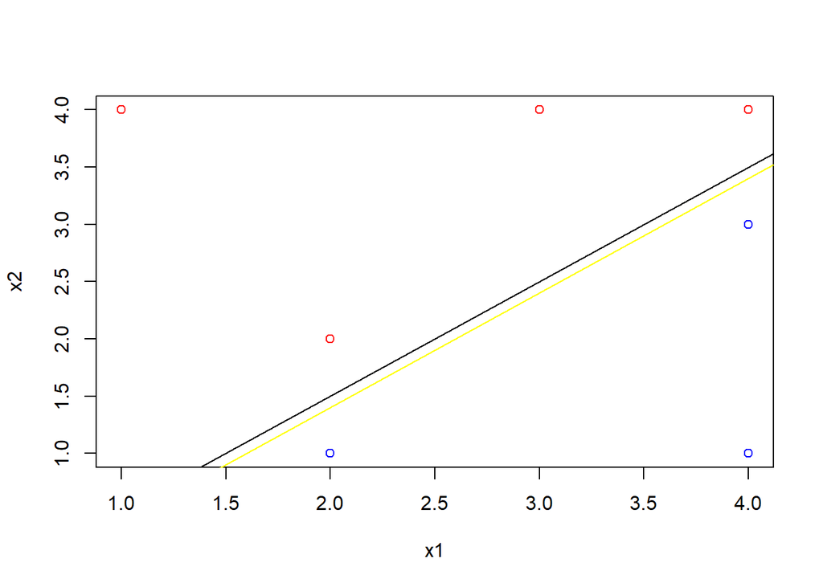

```r
plot(x1, x2, col=y, type = "p")
abline(a= -0.5, b = 1)
abline(a= -0.6, b = 1, col = "yellow")
```

I drawed a yellow line with different intercept(0.6), the equation is: $-0.6 + x1 - x2 = 0 > 0$

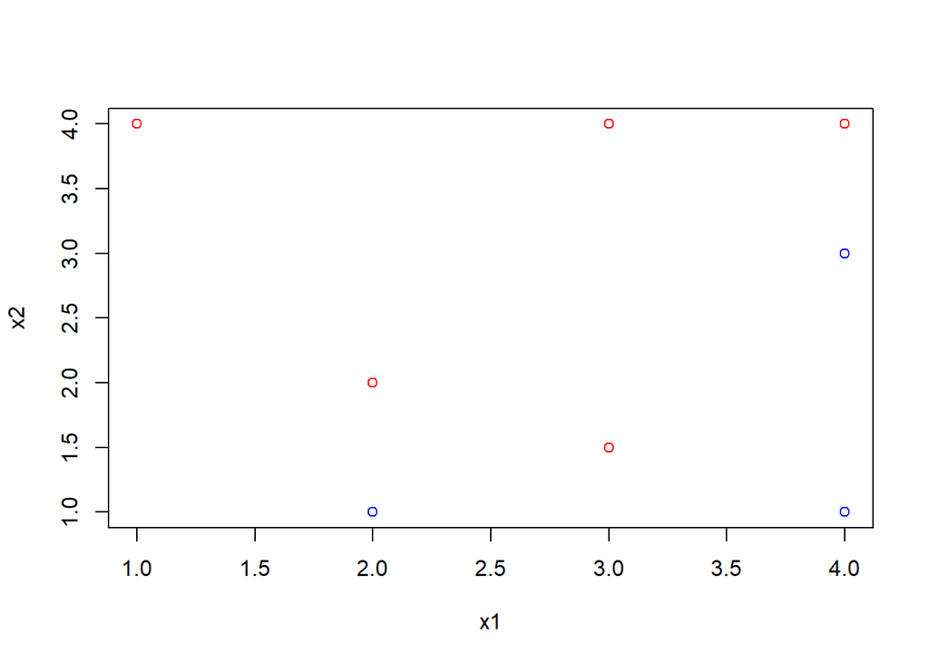

```r
plot(x1, x2, col=y, type = "p")
points(3, 1.5, col="red")
```

I drawed a point at (3, 1.5) in red. In this case they cannot be separated by a hyperplane.